# Análise Exploratória de Dados

Análise Exploratória Gráfica - Parte 2

Autor

Mateus Rezende Bispo

Data de Publicação

11 de junho de 2025

# 1 Gráficos para Visualizar a Distribuição de Variáveis Categóricas

## 1.1 Gráfico de Barras

- Um **gráfico de barras** utiliza barras retangulares para representar a distribuição dos valores de uma variável categórica, com a altura de cada barra proporcional à frequência absoluta ou relativa de cada categoria.
- Estas barras podem ser organizadas verticalmente ou **horizontalmente**.
- É comumente aplicado em análises que envolvem variáveis categóricas ou discretas, facilitando a interpretação e comparação dos valores representados.

## 1.2 Gráfico de Barras Exploratório

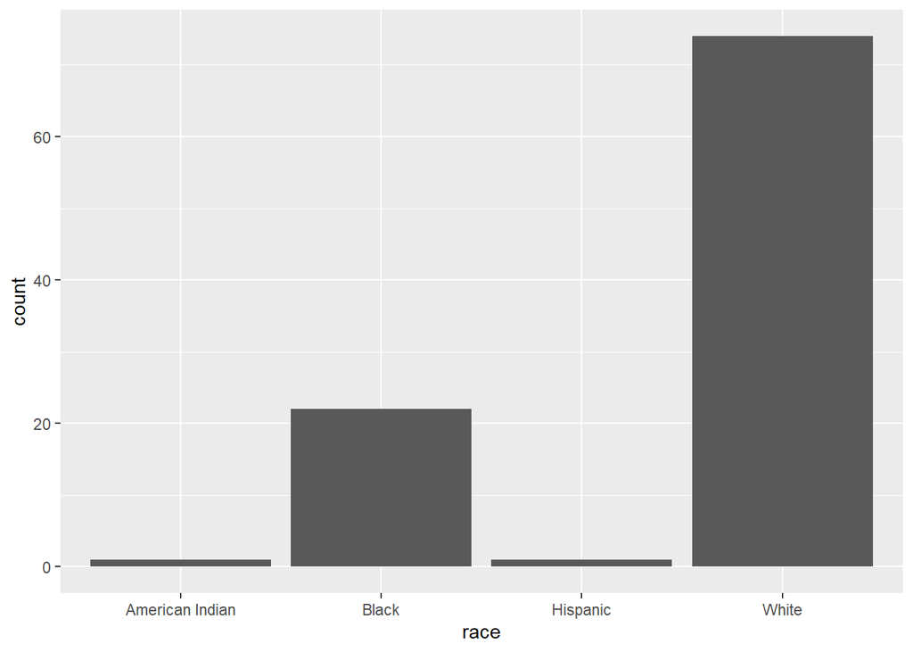

```r
# gráfico de barras simples da distribuição de race
ggplot(Marriage, aes(x = race)) +
  geom_bar()
```

Gráfico de Barras Exploratório com eixos invertidos:

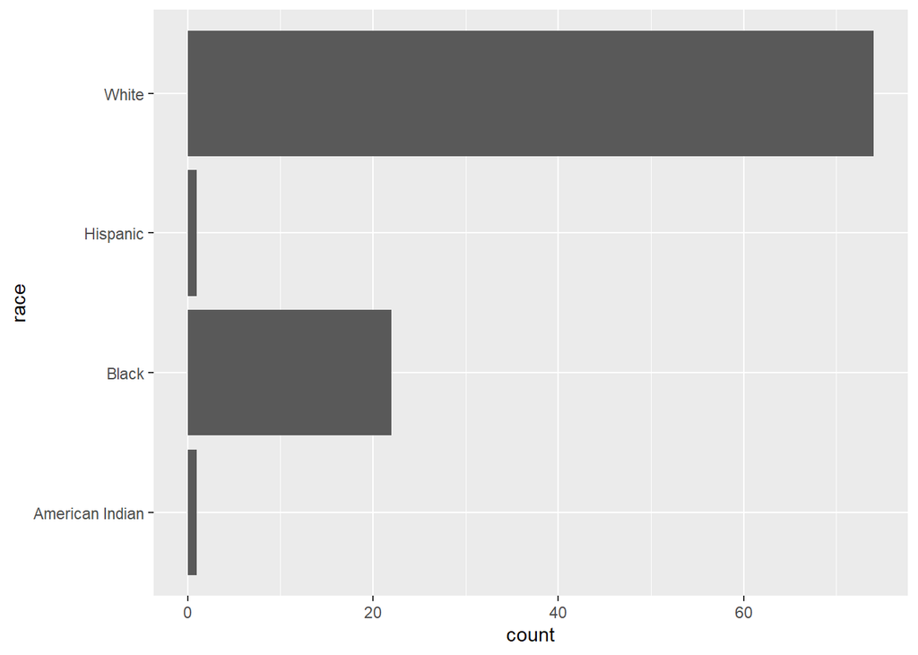

```r
# salva o gráfico no objeto grafico_barras_exploratorio
grafico_barras_simples <-
# gráfico de barras simples da distribuição de raça
ggplot(Marriage, aes(x = race)) +
  geom_bar() +
  # inverte os eixos
  coord_flip()

# exibe o gráfico
grafico_barras_simples
```

- É uma boa prática inverter os eixos de um gráfico de barras para facilitar a leitura, especialmente quando há muitas categorias.

## 1.3 Tabelas de Frequência Exploratória em R

```r
# tabela de frequencia com table
table(Marriage$race)
```

```
American Indian           Black        Hispanic           White
              1              22               1              74
```

## 1.4 Tabela de Frequência com dplyr

```r
# Preparação dos dados para o gráfico

# Calcula o número de participantes em cada nível de raça
tabela_raca_frequencia <- Marriage %>%
  # conta o número de participantes por raça
  count(race) %>%
  # ordena os dados pela frequência em ordem CRESCENTE (menor para maior)
  # vamos usar ordem crescente para compensar o efeito do coord_flip()
  arrange(n) %>%
  # sincroniza os niveis do factor com a ordem atual das linhas
  mutate(race = factor(race, levels = race))

# exibe a tabela (dados em ordem crescente)
tabela_raca_frequencia
```

```
             race  n
1 American Indian  1
2        Hispanic  1
3           Black 22
4           White 74
```

## 1.5 Gráfico de Barras com Rótulos nas Barras - Frequência Absoluta

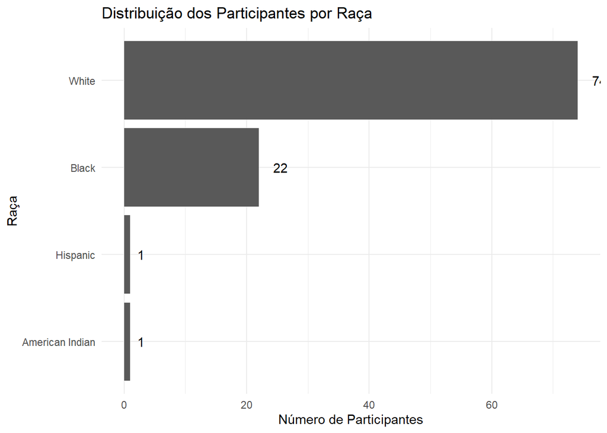

```r
# Salva o gráfico em objeto
grafico_barras_freq <-
# Cria um sistema de coordenadas para o gráfico com x sendo a raça e y sendo a frequência
ggplot(tabela_raca_frequencia, aes(x = race, y = n)) +
  # Cria o gráfico de barras
  # stat="identity" usa os valores exatos de x = 'n' (frequência)
  geom_bar(stat="identity") +
  # Inverte os eixos
  coord_flip() +
  # geom_text() adiciona rótulos (frequência) às barras
  # hjust = -0.5: posiciona o texto um pouco à direita das barras horizontais
  geom_text(aes(label = n), hjust = -1) +
  # Adiciona rótulos aos eixos e título do gráfico
  labs(x = "Raça",
       y = "Número de Participantes",
       title  = "Distribuição dos Participantes por Raça") +
  # Define um tema minimalista para o gráfico
  theme_minimal()

# Exibe o gráfico
grafico_barras_freq
```

## 1.6 Gráfico de Barras com Rótulos nas Barras - Porcentagem

```r
# Preparação dos dados para o gráfico

# Calcula o número e a porcentagem de participantes em cada nível de raça
tabela_raca_porcentagem <- Marriage %>%
  # conta o número de participantes por raça
  count(race) %>%
  # calcula a porcentagem de cada categoria
  # divide cada frequência (n) pelo total de observações
  mutate(porcentagem = n / sum(n)) %>%
  # ordena os dados pela frequência em ordem CRESCENTE (menor para maior)
  # vamos usar ordem crescente para compensar o efeito do coord_flip()
  arrange(n) %>%
  # sincroniza os niveis do factor com a ordem atual das linhas
  mutate(race = factor(race, levels = race))

# exibe a tabela (agora com frequência e porcentagem)
tabela_raca_porcentagem
```

```
             race  n porcentagem
1 American Indian  1 0.010204082
2        Hispanic  1 0.010204082
3           Black 22 0.224489796
4           White 74 0.755102041
```

## 1.7 Gráfico de Barras com Rótulos nas Barras - Porcentagem

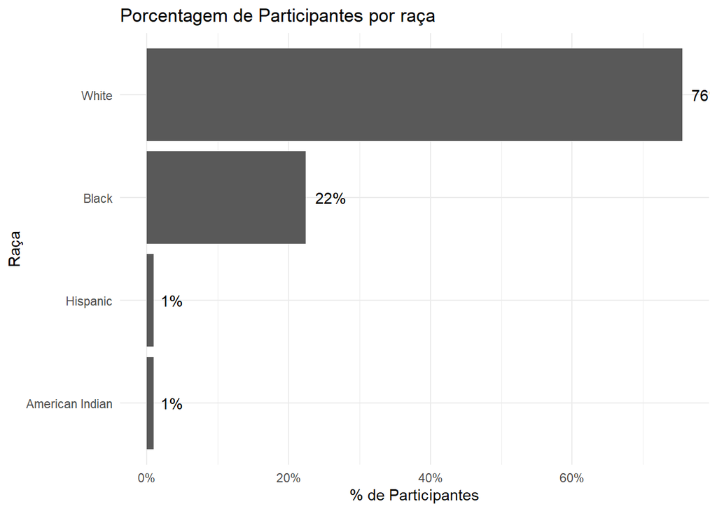

```r
# Salva o gráfico em objeto
grafico_barras_pct <-
# Cria um sistema de coordenadas para o gráfico com x sendo a raça e y sendo a %
ggplot(tabela_raca_porcentagem,
       aes(x = race, y = porcentagem)) +
  # Cria o gráfico de barras
  # stat="identity" usa os valores exatos de x = 'porcentagem'
  geom_bar(stat = "identity") +
  # inverte os eixos para barras horizontais (e ordem decrescente visual)
  coord_flip() +
   # geom_text() adiciona rótulos às barras
   # hjust = -0.3 posiciona o texto à direita das barras horizontais
   # scales::percent converte para porcentagem 0.25 → 25%
   geom_text(aes(label = scales::percent(porcentagem)),
            hjust = -0.3) +
  # scale_y_continuous() define a formatação do eixo y
  # scales::percent converte os valores do eixo y para porcentagens
  scale_y_continuous(labels = scales::percent) +
  # Adiciona rótulos aos eixos e título do gráfico
  labs(x = "Raça",
       y = "% de Participantes",
       title  = "Porcentagem de Participantes por raça") +
  # Define um tema minimalista para o gráfico
  theme_minimal()


# exibe o gráfico
grafico_barras_pct
```

## 1.8 Gráfico de Barras para Publicação - Frequência

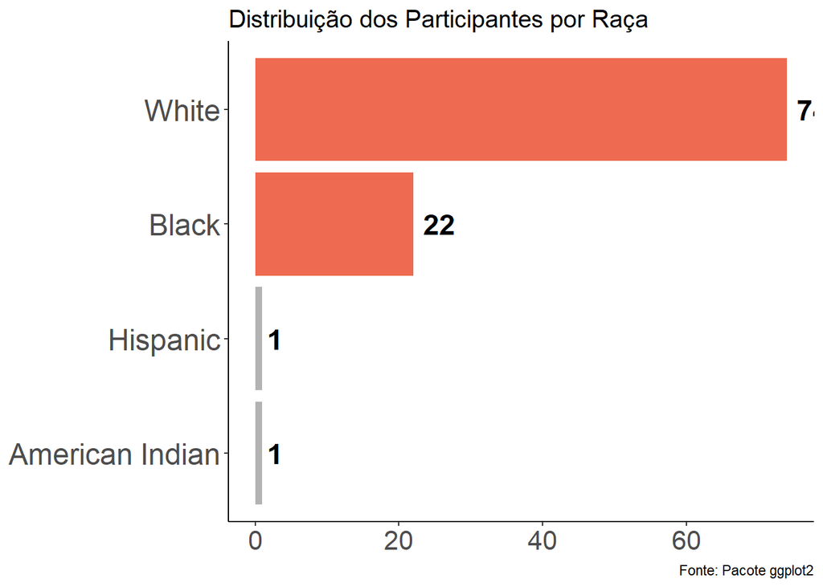

```r
# Salva o gráfico em objeto
grafico_barras_freq_pub <-
# Cria sistema de coordenadas: x = raça, y = frequência, fill = cores por categoria
ggplot(tabela_raca_frequencia, aes(x = race, y = n, fill = race)) +
  # Cria barras usando geom_bar com stat="identity"
  geom_bar(stat = "identity") +
  # Inverte os eixos (barras horizontais)
  coord_flip() +
  # Adiciona rótulos de frequência nas barras
  # hjust = -0.1: posiciona o texto DO LADO DIREITO das barras (parte superior)
  # size = 6 e fontface = "bold" para melhor legibilidade
  geom_text(aes(label = n),
            hjust = -0.3,
            size = 6,
            fontface = "bold") +
  # Define cores personalizadas para cada categoria de raça
  scale_fill_manual(
    values = c(
      "White" = "coral2",
      "Black" = "coral2",
      "Hispanic" = "grey70",
      "American Indian" = "grey70"
    )
  ) +
  # Aplica tema clássico (fundo branco, bordas pretas)
  theme_classic() +
  # Personaliza elementos visuais para qualidade de publicação
  theme(
    legend.position = "none",              # remove legenda (cores já identificam)
    plot.title = element_text(size = 15),  # título com fonte 15
    axis.text.y = element_text(size = 18), # rótulos eixo Y (raças) fonte 18
    axis.text.x = element_text(size = 16), # rótulos eixo X (números) fonte 16
    axis.title.x = element_blank(),        # remove título do eixo X
    axis.title.y = element_blank()         # remove título do eixo Y
  ) +
  # Define título e fonte
  labs(title = "Distribuição dos Participantes por Raça",
       caption = "Fonte: Pacote ggplot2")

# Exibe o gráfico
grafico_barras_freq_pub
```

## 1.9 Gráfico de Barras para Publicação - Porcentagem

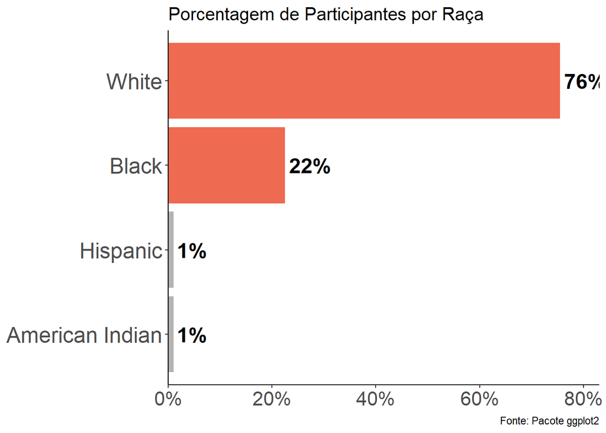

```r
# Salva o gráfico em objeto
grafico_barras_pct_pub <-
# Cria sistema de coordenadas: x = raça, y = porcentagem, fill = cores por categoria
ggplot(tabela_raca_porcentagem,
       aes(x = race, y = porcentagem, fill = race)) +
  # Cria barras usando geom_bar com stat="identity"
  geom_bar(stat = "identity") +
  # Inverte os eixos para barras horizontais (e ordem decrescente visual)
  coord_flip() +
  # Adiciona rótulos de porcentagem nas barras
  # hjust = -0.1: posiciona o texto DO LADO DIREITO das barras (parte superior)
  # size = 6 e fontface = "bold" para melhor legibilidade
  # scales::percent() formata como porcentagem (0.25 → 25%)
  geom_text(aes(label = scales::percent(porcentagem)),
            hjust = -0.1,
            size = 6,
            fontface = "bold") +
  # Define cores específicas para cada categoria de raça
  scale_fill_manual(
    values = c(
      "White" = "coral2",
      "Black" = "coral2",
      "Hispanic" = "grey70",
      "American Indian" = "grey70"
    )
  ) +
  # Formata o eixo y como porcentagem E amplia o limite para acomodar os rótulos
  # expand = expansion(mult = c(0, 0.1)) adiciona 10% de espaço extra no limite superior
  scale_y_continuous(labels = scales::percent,
                     expand = expansion(mult = c(0, 0.1))) +
  # Aplica tema clássico (fundo branco, bordas pretas)
  theme_classic() +
  # Personaliza elementos visuais para qualidade de publicação
  theme(
    legend.position = "none",              # remove legenda (cores já identificam)
    plot.title = element_text(size = 15),  # título com fonte 15
    axis.text.y = element_text(size = 18), # rótulos eixo Y (raças) fonte 18
    axis.text.x = element_text(size = 16), # rótulos eixo X (%) fonte 16
    axis.title.x = element_blank(),        # remove título do eixo X
    axis.title.y = element_blank()         # remove título do eixo Y
  ) +
  # Define título e fonte
  labs(title = "Porcentagem de Participantes por Raça",
       caption = "Fonte: Pacote ggplot2")

# Exibe o gráfico
grafico_barras_pct_pub
```

# 2 Gráficos Bivariados - Variável Categórica vs Variável Categórica

## 2.1 Gráficos de Barras Agrupadas

- Os gráficos de barras agrupadas são úteis para comparar a distribuição de uma variável categórica em relação a outra variável categórica.
- No entanto, eles possuem algumas desvantagens que podem impactar sua eficácia e interpretação.
- Por exemplo: Se uma ou ambas as variáiveis contém muitos valores possíveis (níveis), isso pode tornar o gráfico difícil de ler e interpretar.
- Recomendado apenas em casos com poucos valores possíveis (níveis) para cada variável categórica.
- **Gráficos condicionais (facetas)**, são melhores do que gráficos de barras agrupadas.

## 2.2 Tabela de Contingência com table()

```r
# Cria tabela de contingência exploratória entre raça e signo astrológico
tabela_contingencia <- table(Marriage$race, Marriage$sign)
tabela_contingencia
```

```
                  Aquarius Aries Cancer Capricorn Gemini Leo Libra Pisces
  American Indian        0     0      0         0      0   0     0      0
  Black                  1     2      1         0      4   3     4      2
  Hispanic               0     0      0         0      0   0     0      1
  White                  6     8      7         2      5   4     3     13

                  Saggitarius Scorpio Taurus Virgo
  American Indian           1       0      0     0
  Black                     3       0      2     0
  Hispanic                  0       0      0     0
  White                     5       7      4    10
```

```r
# Adiciona os totais marginais
addmargins(tabela_contingencia)
```

```
                  Aquarius Aries Cancer Capricorn Gemini Leo Libra Pisces
  American Indian        0     0      0         0      0   0     0      0
  Black                  1     2      1         0      4   3     4      2
  Hispanic               0     0      0         0      0   0     0      1
  White                  6     8      7         2      5   4     3     13
  Sum                    7    10      8         2      9   7     7     16

                  Saggitarius Scorpio Taurus Virgo Sum
  American Indian           1       0      0     0   1
  Black                     3       0      2     0  22
  Hispanic                  0       0      0     0   1
  White                     5       7      4    10  74
  Sum                       9       7      6    10  98
```

## 2.3 Tabela de Contingência com dplyr

```r
# Preparação dos dados para gráfico de barras agrupadas e empilhadas

# Cria tabela de contingencia entre raça e signo astrológico
tabela_bivariada <- Marriage %>%
  # count() conta as combinações únicas de race e sign
  # sort = TRUE ordena pela frequência em ordem decrescente
  count(race, sign, sort = TRUE)

# exibe a tabela de contingência
tabela_bivariada
```

```
              race        sign  n
1            White      Pisces 13
2            White       Virgo 10
3            White       Aries  8
4            White      Cancer  7
5            White     Scorpio  7
6            White    Aquarius  6
7            White      Gemini  5
8            White Saggitarius  5
9            Black      Gemini  4
10           Black       Libra  4
11           White         Leo  4
12           White      Taurus  4
13           Black         Leo  3
14           Black Saggitarius  3
15           White       Libra  3
16           Black       Aries  2
17           Black      Pisces  2
18           Black      Taurus  2
19           White   Capricorn  2
20 American Indian Saggitarius  1
21           Black    Aquarius  1
22           Black      Cancer  1
23        Hispanic      Pisces  1
```

## 2.4 Gráficos de Barras Agrupadas Exploratório - Frequência

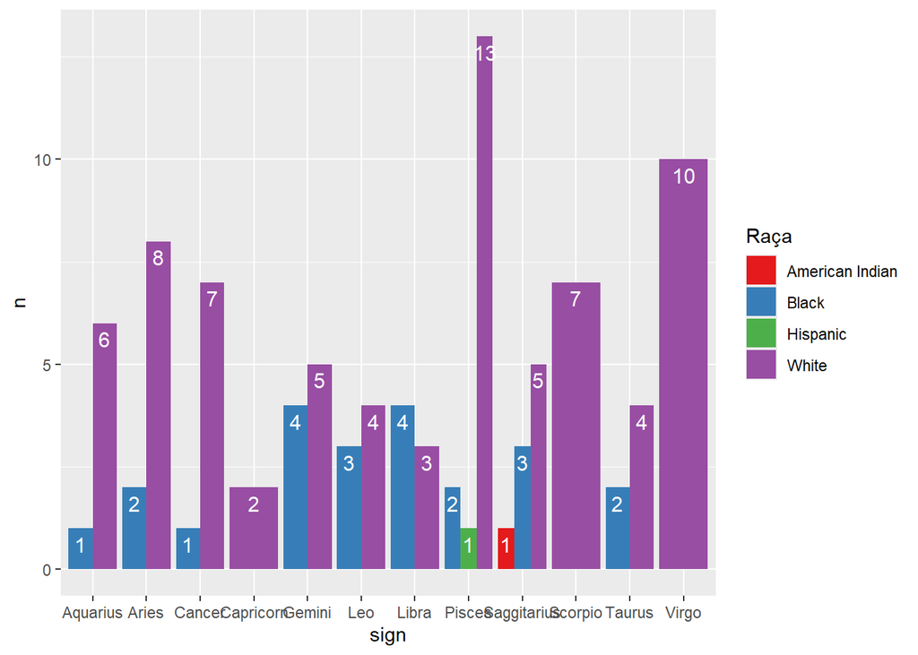

```r
# Salva o gráfico em um objeto
grafico_barras_agrupadas <-
# mapeia a variável 'sign' para o eixo x e a variável 'n' (frequência)
# para o eixo y
# fill = race define as cores das barras por raça
ggplot(tabela_bivariada, aes(x = sign, y = n, fill = race)) +
  # geom_bar() cria o gráfico de barras agrupadas
  # stat = "identity": usa os valores exatos da coluna 'n' (frequências)
  # position = "dodge": agrupa as barras lado a lado
  geom_bar(stat = "identity", position = "dodge") +
  # Adiciona rótulos com os valores de frequência nas barras
  geom_text(
    aes(label = n),              # exibe os valores da coluna 'n'
    colour = "white",            # cor do texto em branco
    size = 4,                    # tamanho da fonte
    vjust = 1.5,                 # posiciona o texto para baixo (dentro das barras)
    position = position_dodge(.9) # alinha o texto com as barras agrupadas
                                  # .9 corresponde à largura padrão do dodge
  ) +
  # Paleta de cores acessível para daltônicos
  scale_fill_brewer(
    name = "Raça",
    type = "qual",
    palette = "Set1"
  )

# Exibe o gráfico
grafico_barras_agrupadas
```

## 2.5 Gráficos de Barras Empilhadas Exploratório - Frequência

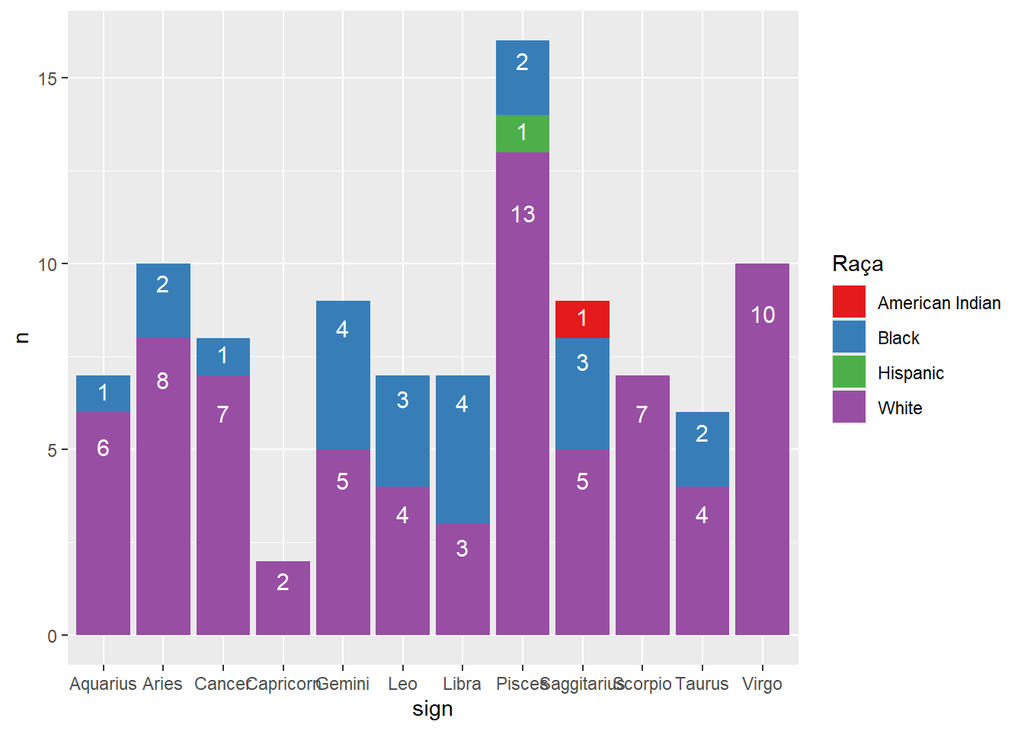

```r
# Criação do gráfico de barras empilhadas
grafico_barras_empilhadas <-
  ggplot(tabela_bivariada, aes(x = sign, y = n, fill = race)) +
  # geom_bar() cria as barras empilhadas
  # stat = "identity": usa os valores exatos da coluna 'n' (frequências)
  # position = "stack": empilha as barras umas sobre as outras (padrão)
  # Diferença do "dodge": em vez de lado a lado, as barras ficam sobrepostas
  geom_bar(stat = "identity", position = "stack") +
  # Adiciona rótulos com os valores de frequência dentro de cada segmento
  geom_text(
    aes(label = n),                # exibe os valores da coluna 'n'
    colour = "white",              # cor do texto em branco (contraste)
    size = 4,                      # tamanho da fonte
    vjust = 1.2,                   # posiciona o texto ligeiramente para baixo
    position = position_stack(.9)  # alinha o texto de cada segmento empilhado
                                  # .9 = posiciona a 90% da altura de cada segmento
  ) +
  # Paleta de cores acessível para daltônicos
  # ColorBrewer "Set1": cores distintas e com bom contraste para texto branco
  scale_fill_brewer(
    name = "Raça",               # título da legenda
    type = "qual",               # qualitative: para variáveis categóricas
    palette = "Set1"             # paleta colorblind-friendly com cores escuras
  )

# Exibe o gráfico
grafico_barras_empilhadas
```

# 3 Gráficos Bivariados - Variável Numérica vs Variável Numérica

## 3.1 Gráfico de Dispersão

- Um gráfico de dispersão, também conhecido como gráfico de pontos, é uma representação gráfica utilizada para exibir a **correlação** entre duas variáveis **numéricas**.
- Ele é composto por um eixo horizontal (eixo x) e um eixo vertical (eixo y), cada um representando uma das variáveis. Os dados são representados como pontos no gráfico, onde a posição de cada ponto é determinada pelos valores das variáveis (x, y).
- Este tipo de gráfico é particularmente útil:
- para identificar padrões de **correlação** entre as variáveis — se é **positiva** (ambas as variáveis aumentam juntas), **negativa** (uma variável aumenta enquanto a outra diminui), ou **nula** (sem relação aparente).
- permite a visualização de **agrupamentos** de dados e a **presença de valores atípicos (outliers)** que podem indicar erros de medição ou peculiaridades no conjunto de dados.

## 3.2 Análise de Correlação em R

### 3.2.1 Função `cor`

- Podemos obter a estimativa de r (Pearson) usando a função interna `cor()`:

```r
r_pearson <- cor(marketing$sales,
                 marketing$youtube,
                 method = "pearson")
round(r_pearson, digits = 2)
```

```
[1] 0.78
```

```r
effectsize::interpret_r(r_pearson, rules = "cohen1988")
```

```
[1] "large"
(Rules: cohen1988)
```

## 3.3 Gráfico de Dispersão Exploratório

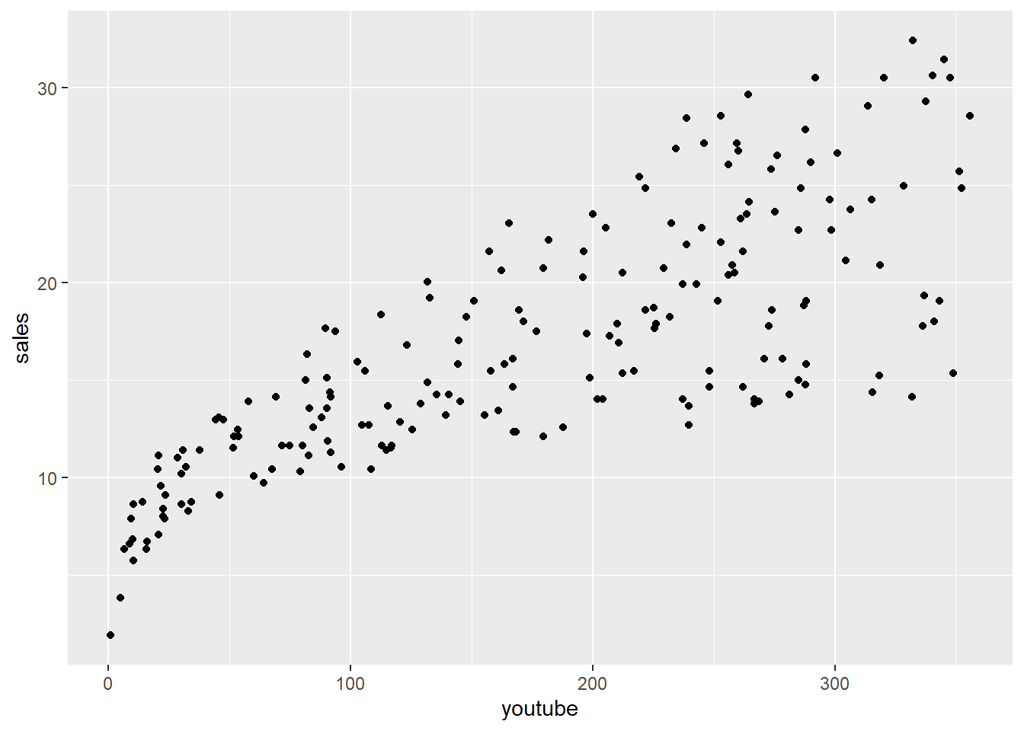

```r
# Salva o gráfico em um objeto
grafico_dispersao_simples <-
# mapeia o orçamento de marketing no YouTube para o eixo x e
# as vendas para o eixo y
ggplot(marketing, aes(x = youtube, y = sales)) +
  # Adicona um gráfico de dispersão de sales vs youtube
  geom_point()

# exibe o gráfico
grafico_dispersao_simples
```

## 3.4 Gráfico de Dispersão com Reta de Regressão

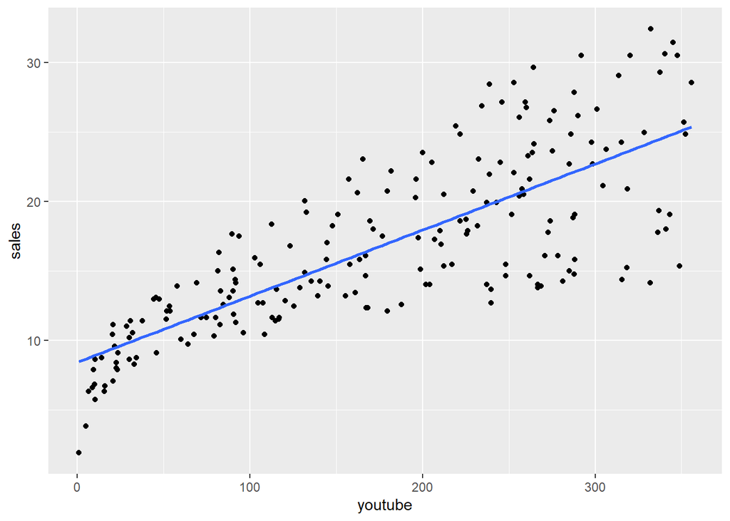

```r
# Salva o gráfico em um objeto
grafico_dispersao_reta <-
# mapeia o orçamento de marketing no YouTube para o eixo x e
# as vendas para o eixo y
ggplot(marketing, aes(x = youtube, y = sales)) +
  # Adiciona o gráfico de dispersão de sales vs youtube
  geom_point() +
  # Adiciona a reta de regressão linear
  # se = FALSE desativa o intervalo de confiança
  geom_smooth(method = "lm", se = FALSE)

# exibe o gráfico
grafico_dispersao_reta
```

## 3.5 Gráfico de Dispersão Para Publicação

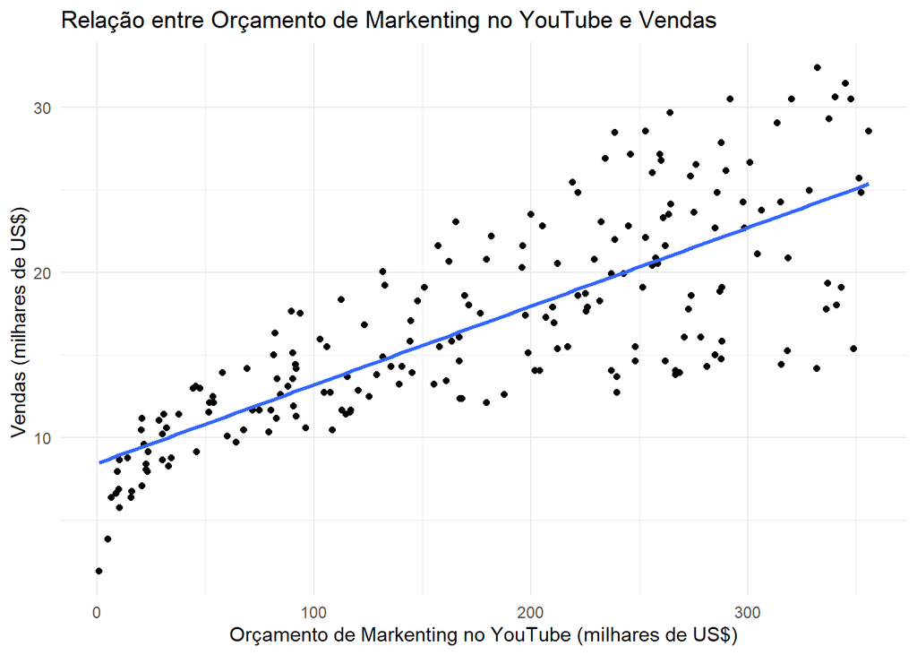

```r
# Salva o gráfico em um objeto
grafico_dispersao_pub <-
ggplot(marketing, aes(x = youtube, y = sales)) +
  geom_point() +
  geom_smooth(method = "lm", se = FALSE) +
  labs(
    title = "Relação entre Orçamento de Markenting no YouTube e Vendas",
    x = "Orçamento de Markenting no YouTube (milhares de US$)",
    y = "Vendas (milhares de US$) "
  )  +
  theme_minimal()

# Exibe o gráfico
grafico_dispersao_pub
```

# 4 Gráficos para Séries Temporais

## 4.1 Gráficos para Séries Temporais

### 4.1.1 Tipos

- Um gráfico pode ser um veículo poderoso para exibir mudanças de um processo aleatório ao longo do tempo, e para identificar padrões, tendências e sazonalidades.
- O gráfico mais comum para séries temporais é o **gráfico de linha**. Outras opções incluem grráficos dumbbell, gráficos de área, entre outros.

## 4.2 Gráfico de Linha Exploratório

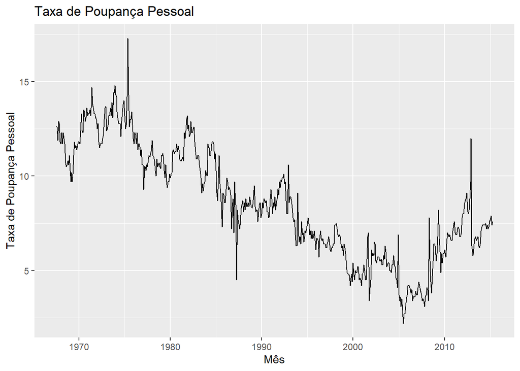

```r
# Salva o gráfico em um objeto
grafico_linha <-
# Mapeia variáveis para os eixos x e y
ggplot(economics, aes(x = date, y = psavert)) +
  # Adiciona um gráfico de linha
  geom_line() +
  # Adiciona título e rótulos aos eixos
  labs(title = "Taxa de Poupança Pessoal",
       x = "Mês",
       y = "Taxa de Poupança Pessoal")

# Exibe o gráfico
grafico_linha
```

## 4.3 Gráfico de Linha para Publicação 1

### 4.3.1 Melhorias 1

- Vamos usar função `scale_x_date` para alterar como as datas são exibidas no eixo x para que reflitam a periodicidade mensal, vamos estabelecer marcas a cada 5 anos e as datas serão apresentadas no formato MM-AA.
- Além disso, vamos atribuir um tom de vermelho para a linha e aumentar sua espessuara.
- E, como sempre, vamos adotar um tema minimalista para o gráfico.

## 4.4 Gráfico de Linha para Publicação 1

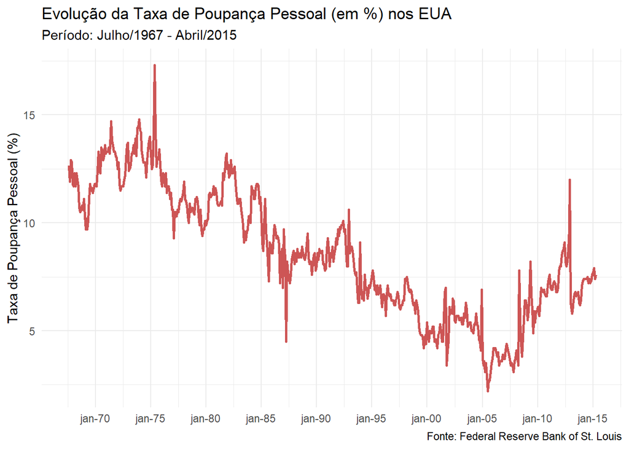

```r
# Salva o gráfico em um objeto
grafico_linha_pub <-
# Mapeia variáveis para os eixos x e y
ggplot(economics, aes(x = date, y = psavert)) +
  # Adiciona um gráfico de linha
  # color = "indianred3" define a cor da linha
  # size = 1 define a espessura da linha
  geom_line(color = "indianred3",
            size= 1 ) +
  # NOVA: Formata o eixo x para exibir datas a cada 5 anos
  # date_breaks = '5 years' define os intervalos de 5 anos
  # labels = date_format("%b-%y") formata as datas como mês-ano
  scale_x_date(date_breaks = '5 years',
               labels = date_format("%b-%y")) +
  # Adiciona título e rótulos aos eixos
  labs(title = "Evolução da Taxa de Poupança Pessoal (em %) nos EUA",
       subtitle = "Período: Julho/1967 - Abril/2015",
       x = NULL,
       y = "Taxa de Poupança Pessoal (%)",
       caption = "Fonte: Federal Reserve Bank of St. Louis") +
  # Define um tema minimalista para o gráfico
  theme_minimal()

# Exibe o gráfico
grafico_linha_pub
```

### 4.4.1 Melhorias 2

- Por fim, vamos adicionar uma curva (modelo) não paramétrica para facilitar a visualização de tendências de longo prazo.
- A curva não paramétrica é uma linha suavizada que ajuda a identificar tendências gerais nos dados, independentemente de flutuações sazonais ou ruídos de curto prazo.

## 4.5 Gráfico de Linha para Publicação 2

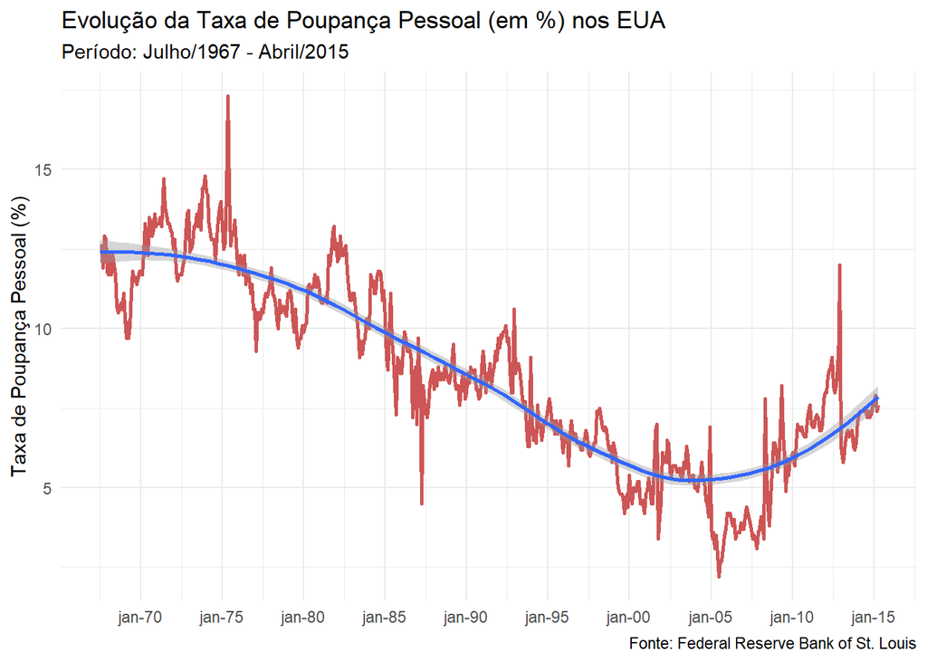

```r
# Salva o gráfico em um objeto
grafico_linha_pub <-
# Mapeia variáveis para os eixos x e y
ggplot(economics, aes(x = date, y = psavert)) +
  # Adiciona um gráfico de linha
  # color = "indianred3" define a cor da linha
  # size = 1 define a espessura da linha
  geom_line(color = "indianred3",
            size= 1 ) +
  # NOVA: Adiciona uma curva não paramétrica
  geom_smooth() +
  # Formata o eixo x para exibir datas a cada 5 anos
  # date_breaks = '5 years' define os intervalos de 5 anos
  # labels = date_format("%b-%y") formata as datas como mês-ano
  scale_x_date(date_breaks = '5 years',
               labels = date_format("%b-%y")) +
  # Adiciona título e rótulos aos eixos
  labs(title = "Evolução da Taxa de Poupança Pessoal (em %) nos EUA",
       subtitle = "Período: Julho/1967 - Abril/2015",
       x = NULL,
       y = "Taxa de Poupança Pessoal (%)",
       caption = "Fonte: Federal Reserve Bank of St. Louis") +
  # Define um tema minimalista para o gráfico
  theme_minimal()

# Exibe o gráfico
grafico_linha_pub
```

## 4.6 Gráficos de Linha para 2 Séries Temporais

- Gráficos de linhas para duas, três ou mais séries podem ser eficazes quando as séries têm a **mesma periodicidade** (e.g., mensal, trimestral) e são **medidas na mesma escala ou unidade de medida**.
- É importante garantir que as séries sejam comparáveis e que não haja diferenças significativas em suas escalas, pois isso pode distorcer a interpretação dos dados.

## 4.7 Gráficos de Linha para 2 Séries

```r
# salva as séries importadas no objeto serie_bivariada
serie_bivariada <- c("AAPL", "META") %>%
  # obtem os dados de fechamento das ações
  tq_get(from = "2024-01-01") %>%
  # seleciona as colunas relevantes
  select(symbol, date, close) %>%
  # renomeia as colunas para facilitar a leitura
  rename(
    Compania = symbol,
    Dia = date,
    Fechamento = close
  )

# Exibe as 6 primeiras linhas da data frame
head(serie_bivariada)
```

```
# A tibble: 6 × 3
  Compania Dia        Fechamento
  <chr>    <date>          <dbl>
1 AAPL     2024-01-02       186.
2 AAPL     2024-01-03       184.
3 AAPL     2024-01-04       182.
4 AAPL     2024-01-05       181.
5 AAPL     2024-01-08       186.
6 AAPL     2024-01-09       185.
```

Exibe as 6 últimas linhas da data frame:

```r
tail(serie_bivariada)
```

```
# A tibble: 6 × 3
  Compania Dia        Fechamento
  <chr>    <date>          <dbl>
1 META     2025-06-06       698.
2 META     2025-06-09       694.
3 META     2025-06-10       702.
4 META     2025-06-11       694.
5 META     2025-06-12       693.
6 META     2025-06-13       683.
```

## 4.8 Gráficos de Linha para 2 Séries

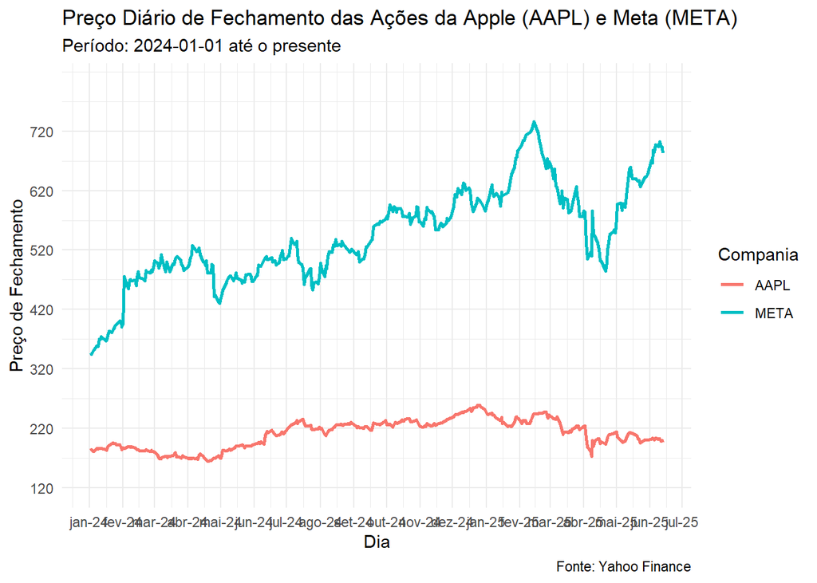

```r
# salva o gráfico em um objeto
grafico_linha_multiseries <-
# mapeia as variáveis para os eixos x e y, e define a cor por empresa
ggplot(serie_bivariada,
       aes(x = Dia, y = Fechamento, color = Compania)) +
  # Adiciona um gráfico de linha
  # size=1 define a espessura da linha
  geom_line(size=1) +
  # Formata o eixo x para exibir datas a cada mês-ano
  scale_x_date(date_breaks = '1 month',
               labels = scales::date_format("%b-%y")) +
  # Formata o eixo y para exibir os preços de fechamento
  # limits = c(120, 800) define os limites do eixo y
  # breaks = seq(120, 800, 100) define os intervalos de 100
  scale_y_continuous(limits = c(120, 800),
                     breaks = seq(120, 800, 100)
                    ) +
  # Adiciona título e rótulos aos eixos
  labs(title = "Preço Diário de Fechamento das Ações da Apple (AAPL) e Meta (META)",
       subtitle = "Período: 2024-01-01 até o presente",
       caption = "Fonte: Yahoo Finance",
       y = "Preço de Fechamento") +
  # Define um tema minimalista para o gráfico
  theme_minimal()

# Exibe o gráfico
grafico_linha_multiseries
```

# 5 Exercícios

## 5.1 Exercício 1

### 5.1.1 Gráfico de Barras para 1 Variável Categórica

**Objetivo**: Criar um gráfico de barras para visualizar o número de respondentes por estado civil.

**Instruções**:

```r
# Preparação dos dados para o gráfico

# Calcula o número de participantes em cada nível de raça
tabela_raca_frequencia <- Marriage %>%
  # conta o número de participantes por raça
  count(race) %>%
  # ordena os dados pela frequência em ordem CRESCENTE (menor para maior)
  # vamos usar ordem crescente para compensar o efeito do coord_flip()
  arrange(n) %>%
  # sincroniza os niveis do factor com a ordem atual das linhas
  mutate(race = factor(race, levels = race))

# exibe a tabela (dados em ordem crescente)
tabela_raca_frequencia
```

```
             race  n
1 American Indian  1
2        Hispanic  1
3           Black 22
4           White 74
```

2. Crie um gráfico de barras horizontais básico:

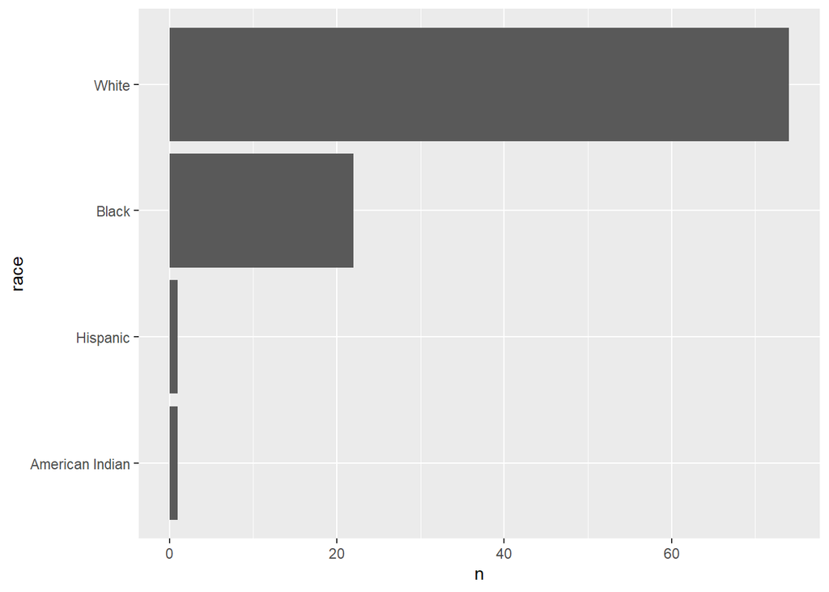

```r
# Gráfico de barras horizontais básico da frequência por raça
ggplot(tabela_raca_frequencia, aes(x = race, y = n)) +
  geom_bar(stat = "identity") +
  coord_flip()
```

3. Melhore o gráfico adicionando:
   - os valores da frequência absoluta nas barras usando `geom_text()`
   - Título e rótulos apropriados dos eixos com `labs(title = "...")`
   - Tema minimalista com `theme_minimal()`

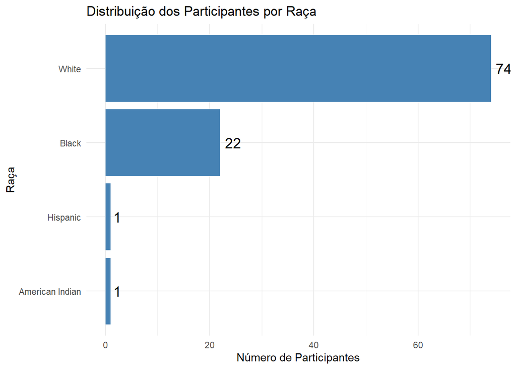

```r
ggplot(tabela_raca_frequencia, aes(x = race, y = n)) +
  geom_bar(stat = "identity", fill = "steelblue") +    # barras azuis só para dar um destaque
  coord_flip() +
  geom_text(aes(label = n), hjust = -0.3, size = 5) +  # coloca os valores no final das barras
  labs(
    title = "Distribuição dos Participantes por Raça",
    x = "Raça",
    y = "Número de Participantes"
  ) +
  theme_minimal()
```

## 5.2 Exercício 2

### 5.2.1 Gráfico de Linha para 1 Série Temporal

**Objetivo**: Importar dados reais do preço da ação da Petrobras (PETR4) a partir do dia 2024-01-01 e criar um gráfico de linha usando os pacotes `tidyquant` e `ggplot2`.

**Instruções**:

1. Importe os dados da Petrobras usando a função `tq_get()` do pacote `tidyquant` e selecione as colunas `date` e `close`:

```r
# Importa os dados da PETR4 a partir de 2024-01-01
dados_petr4 <- tq_get("PETR4.SA", from = "2024-01-01") %>%
  select(date, close)

# Exibe as primeiras linhas para conferir
head(dados_petr4)
```

```
# A tibble: 6 × 2
  date       close
  <date>     <dbl>
1 2024-01-02  37.8
2 2024-01-03  39.0
3 2024-01-04  38.6
4 2024-01-05  38.7
5 2024-01-08  38.4
6 2024-01-09  38.1
```

2. Examine as primeiras linhas da data frame resultante:

```r
head(dados_petr4)
```

```
# A tibble: 6 × 2
  date       close
  <date>     <dbl>
1 2024-01-02  37.8
2 2024-01-03  39.0
3 2024-01-04  38.6
4 2024-01-05  38.7
5 2024-01-08  38.4
6 2024-01-09  38.1
```

3. Crie um gráfico de linha básico:

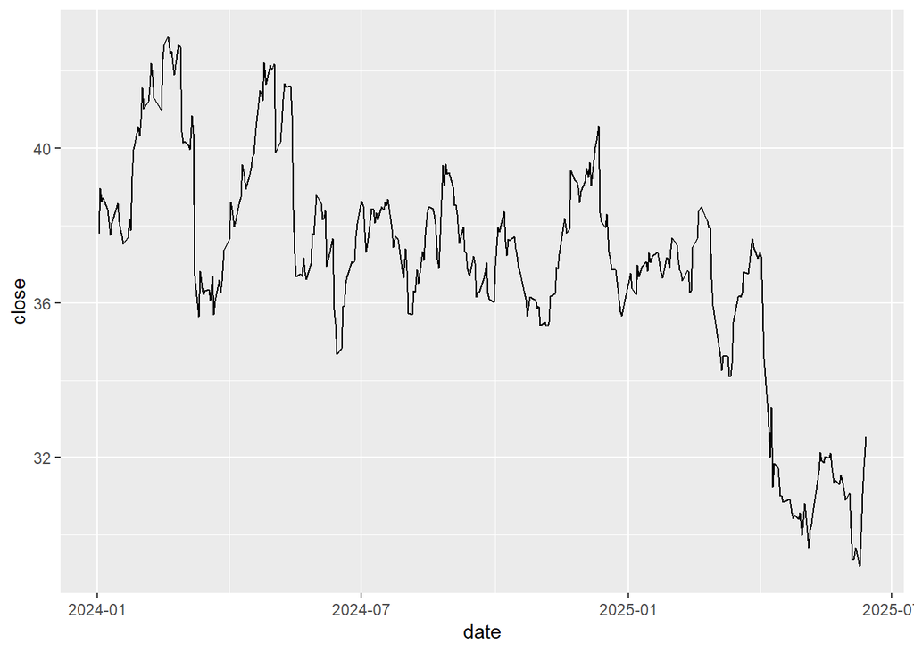

```r
ggplot(dados_petr4, aes(x = date, y = close)) +
  geom_line()
```

4. Melhore o gráfico adicionando:
   - Título: “Evolução do Preço das Ações da Petrobras (PETR4)”
   - Rótulos dos eixos: “Dia” e “Preço de Fechamento (R$)”
   - Tema minimalista
   - Fonte dos dados: “Fonte: Yahoo Finance”

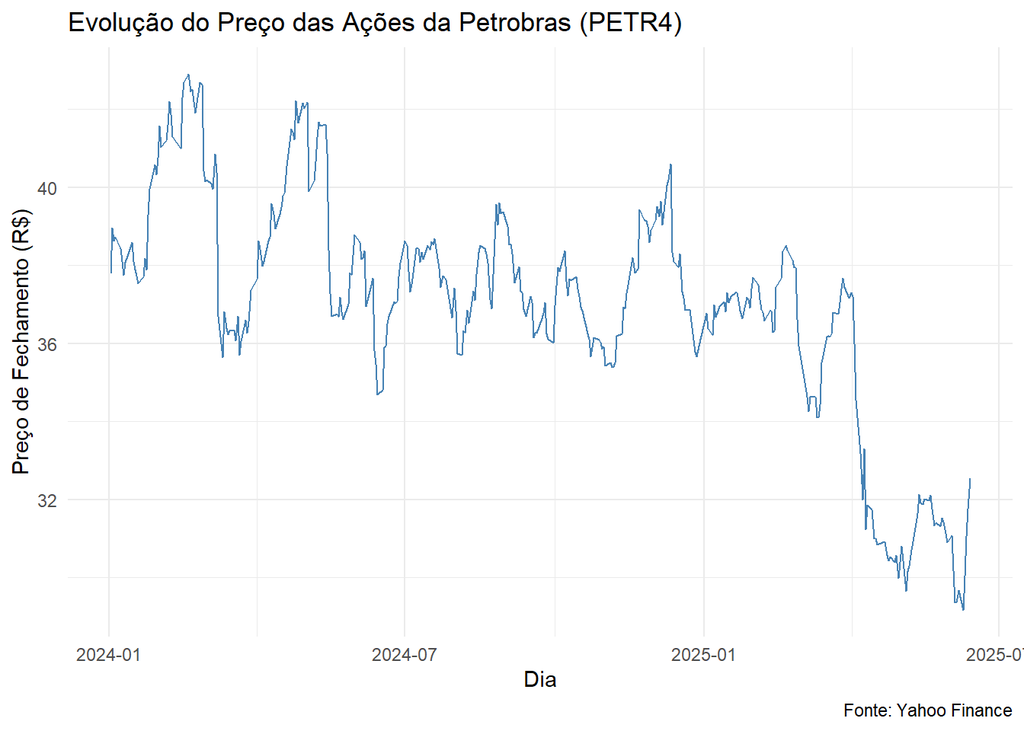

```r
ggplot(dados_petr4, aes(x = date, y = close)) +
  geom_line(color = "steelblue") +
  labs(
    title = "Evolução do Preço das Ações da Petrobras (PETR4)",
    x = "Dia",
    y = "Preço de Fechamento (R$)",
    caption = "Fonte: Yahoo Finance"
  ) +
  theme_minimal()
```

5. Adicione uma curva não paramétrica com a função `geom_smooth()` para visualizar a tendência geral. Mude a cor da linha da série para `"indianred3"` e aumente a espessura da linha para 1

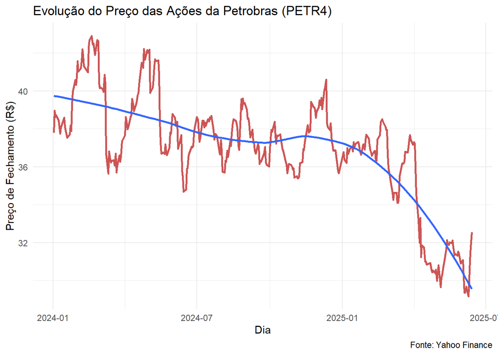

```r
ggplot(dados_petr4, aes(x = date, y = close)) +
  geom_line(color = "indianred3", size = 1) +
  geom_smooth(se = FALSE) +
  labs(
    title = "Evolução do Preço das Ações da Petrobras (PETR4)",
    x = "Dia",
    y = "Preço de Fechamento (R$)",
    caption = "Fonte: Yahoo Finance"
  ) +
  theme_minimal()
```

## 5.3 Preparação de Dados: pivot_wider()

### 5.3.1 Função pivot_wider() do tidyr - Exercício 3

A função `pivot_wider()` transforma dados do formato longo para o formato largo (*wide*),.

**Por que precisamos transformar?**

Para estimar a correlação entre as séries de preços de duas ações, precisamos que cada série de preços seja uma coluna separada, com as datas alinhadas, entretanto, a função tq_get() retorna os dados no formato longo, onde cada linha representa um preço de uma ação em uma data específica, ou seja, as séries de preços estão empilhadas verticalmente.

**Formato Longo** (estrutura retornada pela função `tq_get()`):

```r
dados_longo <-
tibble(
  empresa = c("PETR4.SA", "PETR4.SA", "ITUB4.SA", "ITUB4.SA"),
  data = as.Date(c("2024-01-02", "2024-01-03", "2024-01-02", "2024-01-03")),
  preco = c(35.50, 36.20, 28.30, 28.75)
)

dados_longo
```

```
# A tibble: 4 × 3
  empresa  data       preco
  <chr>    <date>     <dbl>
1 PETR4.SA 2024-01-02  35.5
2 PETR4.SA 2024-01-03  36.2
3 ITUB4.SA 2024-01-02  28.3
4 ITUB4.SA 2024-01-03  28.8
```

**Formato Largo** (necessário para análise de correlação):

```r
dados_largo <-
tibble(
  data = as.Date(c("2024-01-02", "2024-01-03")),
  PETR4.SA = c(35.50, 36.20),
  ITUB4.SA = c(28.30, 28.75)
)

dados_largo
```

```
# A tibble: 2 × 3
  data       PETR4.SA ITUB4.SA
  <date>        <dbl>    <dbl>
1 2024-01-02     35.5     28.3
2 2024-01-03     36.2     28.8
```

**Sintaxe**:

```r
dados_largo <- dados_longo %>%
  pivot_wider(
    names_from = empresa,    # variável que será nomes de colunas
    values_from = preco      # variável com os valores
  )

dados_largo
```

```
# A tibble: 2 × 3
  data       PETR4.SA ITUB4.SA
  <date>        <dbl>    <dbl>
1 2024-01-02     35.5     28.3
2 2024-01-03     36.2     28.8
```

## 5.4 Exercício 3

### 5.4.1 Gráfico de Dispersão com Análise de Correlação

**Objetivo**: Importar dados reais das ações da Petrobras (PETR4) e do Itaú (ITUB4) a partir do dia 2024-01-01, calcular a correlação entre elas e criar um gráfico de dispersão usando os pacotes `tidyquant`, `effectsize` e `ggplot2`.

**Instruções**:

1. Importe os dados das duas empresas de forma compacta usando a função `tq_get()` do pacote `tidyquant`, salve os dados em um objeto chamado `dados_acoes` e mostre as primeiras linhas da data frame resultante:

```r
# Importa dados da Petrobras (PETR4) e Itaú (ITUB4) a partir de 2024-01-01
dados_acoes <- tq_get(c("PETR4.SA", "ITUB4.SA"), from = "2024-01-01") %>%
  select(symbol, date, close) %>%
  rename(empresa = symbol, preco = close)

# Exibe as primeiras linhas da tabela resultante
head(dados_acoes)
```

```
# A tibble: 6 × 3
  empresa  date       preco
  <chr>    <date>     <dbl>
1 PETR4.SA 2024-01-02  37.8
2 PETR4.SA 2024-01-03  39.0
3 PETR4.SA 2024-01-04  38.6
4 PETR4.SA 2024-01-05  38.7
5 PETR4.SA 2024-01-08  38.4
6 PETR4.SA 2024-01-09  38.1
```

2. Transforme os dados para análise de correlação usando `pivot_wider()` e mostre as primeiras linhas da data frame resultante:

```r
dados_correlacao <- dados_acoes %>%
  pivot_wider(
    names_from = empresa,
    values_from = preco
    ) %>%
  rename(petrobras = "PETR4.SA", itau = "ITUB4.SA")

# Exibe os dados transformados
head(dados_correlacao)
```

[output not shown]

3. Calcule a correlação entre os preços das duas ações:

```r
library(tidyr)

# Transforma para formato largo
dados_correlacao <- dados_acoes %>%
  pivot_wider(
    names_from = empresa,
    values_from = preco
  )

# Calcula a correlação de Pearson entre os preços das ações
correlacao <- cor(dados_correlacao$PETR4.SA, dados_correlacao$ITUB4.SA, use = "complete.obs")

correlacao
```

```
[1] -0.60946502
```

4. Interprete a magnitude da correlação usando as regras de Cohen:

```r
# Interpreta a magnitude da correlação de acordo com Cohen (1988)
effectsize::interpret_r(correlacao, rules = "cohen1988")
```

```
[1] "large"
(Rules: cohen1988)
```

5. Crie um gráfico de dispersão básico:

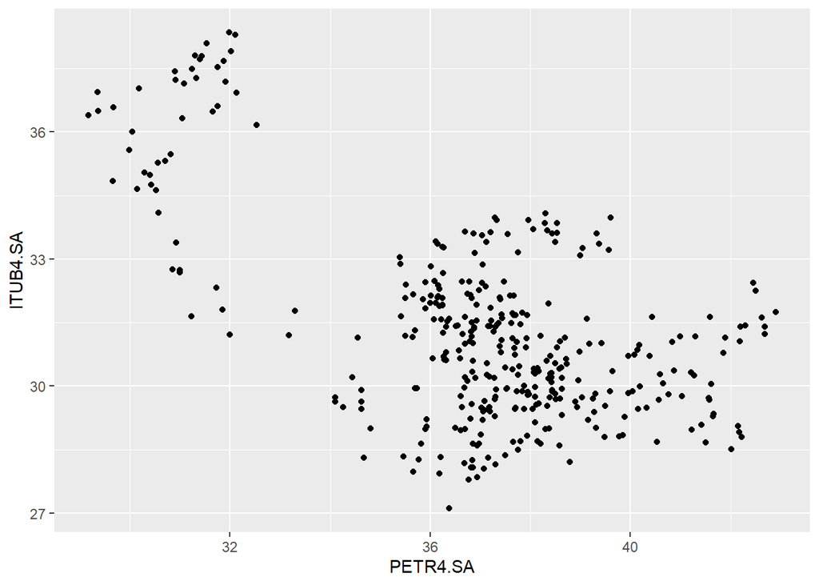

```r
ggplot(dados_correlacao, aes(x = PETR4.SA, y = ITUB4.SA)) +
  geom_point()
```

6. Melhore o gráfico adicionando título, rótulos, reta de regressão e tema:

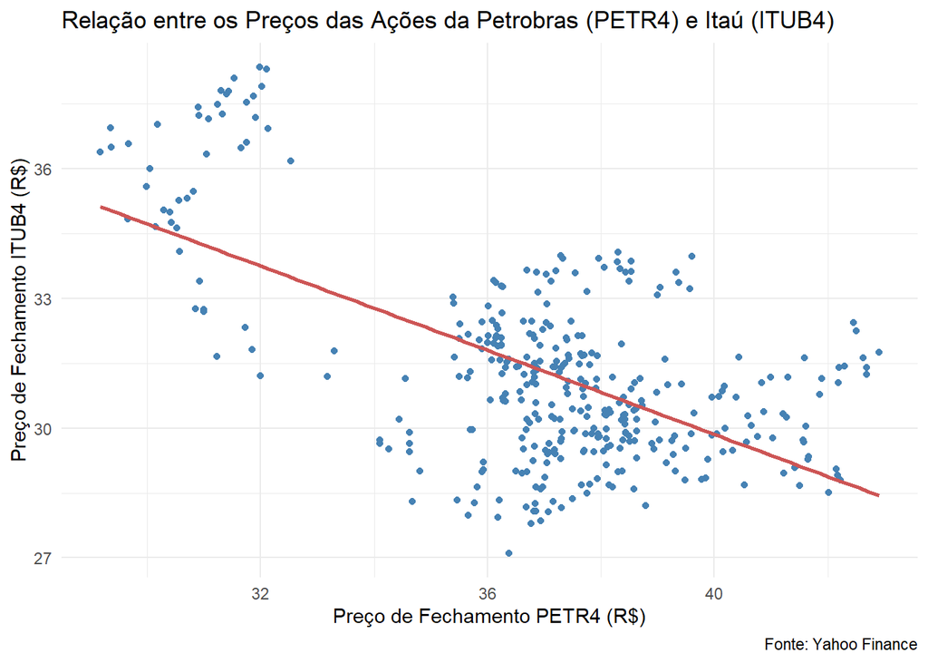

```r
ggplot(dados_correlacao, aes(x = PETR4.SA, y = ITUB4.SA)) +
  geom_point(color = "steelblue") +
  geom_smooth(method = "lm", se = FALSE, color = "indianred3", size = 1) +
  labs(
    title = "Relação entre os Preços das Ações da Petrobras (PETR4) e Itaú (ITUB4)",
    x = "Preço de Fechamento PETR4 (R$)",
    y = "Preço de Fechamento ITUB4 (R$)",
    caption = "Fonte: Yahoo Finance"
  ) +
  theme_minimal()
```

7. Escreva sua interpretação do gráfico de dispersão a partir do coeficiente de correlação de Pearson estimado. Pelo resultado da sua análise, se uma carteira for montada com apenas as ações da Petrobras e do Itaú, seria uma carteira diversificada de investimento em ações?

# 6 Recursos Adicionais

Para aprofundar seus conhecimentos em visualização de dados com ggplot2:

- [Documentação oficial do ggplot2](https://ggplot2.tidyverse.org/)
- [Data Visualization with ggplot2 Cheat Sheet](https://rstudio.com/wp-content/uploads/2015/03/ggplot2-cheatsheet.pdf)
- Livro: “ggplot2: Elegant Graphics for Data Analysis” por Hadley Wickham